# Kaggle Titanic

# 1 Introduction

**Kaggle Introduction:**

The sinking of the Titanic is one of the most infamous shipwrecks in history.

On April 15, 1912, during her maiden voyage, the widely considered “unsinkable” RMS Titanic sank after colliding with an iceberg. Unfortunately, there weren’t enough lifeboats for everyone onboard, resulting in the death of 1502 out of 2224 passengers and crew.

While there was some element of luck involved in surviving, it seems some groups of people were more likely to survive than others.

**Goal:**

The goal of this study is to build a predictive model to accurately predict whether or not a person on the titanic will survive based on a given set of features. Throughout this study we will be using feature engineering techniques and an ensemble method to try to achieve the highest accuracy possible.

# 2 Libraries

```r
library(ggplot2)
library(dplyr)
library(caret)
library(gridExtra)
library(corrplot)
library(stringr)
library(knitr)
#library(gbm)
#library(kernlab)
options(scipen=999)
```

# 3 Loading Datasets

```r
train <- read.csv("train.csv",stringsAsFactors = FALSE)

test <- read.csv("test.csv",stringsAsFactors = FALSE)
head(train)
```

```
##   PassengerId Survived Pclass
## 1           1        0      3
## 2           2        1      1
## 3           3        1      3
## 4           4        1      1
## 5           5        0      3
## 6           6        0      3
##                                                  Name    Sex Age SibSp Parch
## 1                             Braund, Mr. Owen Harris   male  22     1     0
## 2 Cumings, Mrs. John Bradley (Florence Briggs Thayer) female  38     1     0
## 3                              Heikkinen, Miss. Laina female  26     0     0
## 4        Futrelle, Mrs. Jacques Heath (Lily May Peel) female  35     1     0
## 5                            Allen, Mr. William Henry   male  35     0     0
## 6                                    Moran, Mr. James   male  NA     0     0
##             Ticket    Fare Cabin Embarked
## 1        A/5 21171  7.2500              S
## 2         PC 17599 71.2833   C85        C
## 3 STON/O2. 3101282  7.9250              S
## 4           113803 53.1000  C123        S
## 5           373450  8.0500              S
## 6           330877  8.4583              Q
```

```r
table(train$Parch,exclude=FALSE)
```

```
##
##   0   1   2   3   4   5   6
## 678 118  80   5   4   5   1
```

```r
table(train$Embarked,exclude=FALSE)
```

```
##
##       C   Q   S
##   2 168  77 644
```

Passenger ID and ticket number will not be used in this study so will be dropped. After dropping these two variables, the test set consists of 9 predictors and 418 observations, while the train set consists of 9 predictors and 891 observations. The train set also contains the dependent variable ‘Survived’.

```r
train <- train %>% select(-PassengerId,-Ticket)

PassengerId <- test$PassengerId

test <- test %>% select(-PassengerId,-Ticket)
```

Combining the data sets for easy analysis.

```r
#adding survived variable for test with all NA values
test$Survived <- NA
combined <- rbind(train,test)
```

# 4 NA Values

Of the 9 predictors, the age variable contains 263 NA values and fare paid contains 1 NA value. The other 7 predictors have no NA values.

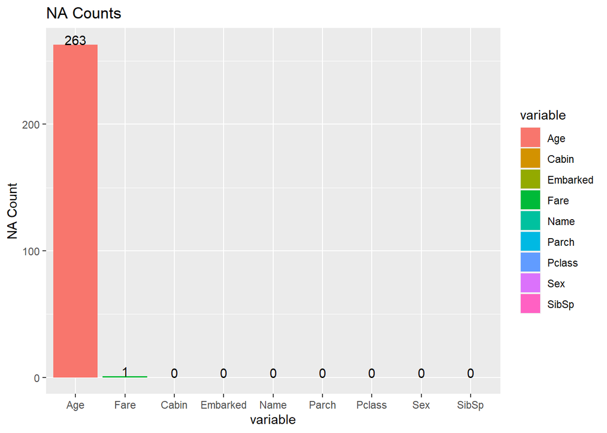

```r
naCounts <- as.data.frame(sapply(combined, function(x) sum(is.na(x))))

naCounts$variable <- row.names(naCounts)
names(naCounts) <- c("naCount","variable")

naCounts <- naCounts %>%
  filter(variable!="Survived")

ggplot(naCounts,aes(x=reorder(variable,desc(naCount)),y=naCount))+
  geom_bar(stat="identity",aes(fill=variable))+
  geom_text(aes(label = naCount), vjust = 0)+
  xlab("variable")+ylab("NA Count")+
  labs(title="NA Counts")
```

# 5 Variable Analysis

## 5.1 Dependent Variable

**Survived:** The dependent variable is whether or not a person survived the sinking of the Titanic. Exists in the train set but not in the test set. Most of the people from the train set died.

- 1 - Survived
- 0 - Died

```r
#percentage died in train set
survivedPercent <- round(sum(combined$Survived==1,na.rm=TRUE)/nrow(train),2)*100
#percentage survived in train set
diedPercent <- round(sum(combined$Survived==0,na.rm=TRUE)/nrow(train),2)*100

print(paste("In the train set",diedPercent,"% died while",survivedPercent,"% survived."))
```

```
## [1] "In the train set 62 % died while 38 % survived."
```

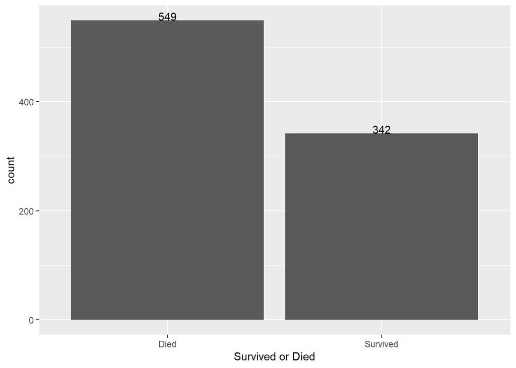

```r
ggplot(combined[!is.na(combined$Survived),],aes(x=as.factor(Survived)))+
  geom_bar()+
  geom_text(stat='count', aes(label=..count..), vjust=0)+
  xlab("Survived or Died")+
  scale_x_discrete(labels = c('Died','Survived'))
```

## 5.2 Independent Variables

**Pclass:** Represents a proxy for socio-economic status. Most people were lower class. Upper class appears to have the highest percent chance to survive, while lower class has the lowest chance to survive.

- 1 = Upper
- 2 = Middle
- 3 = Lower

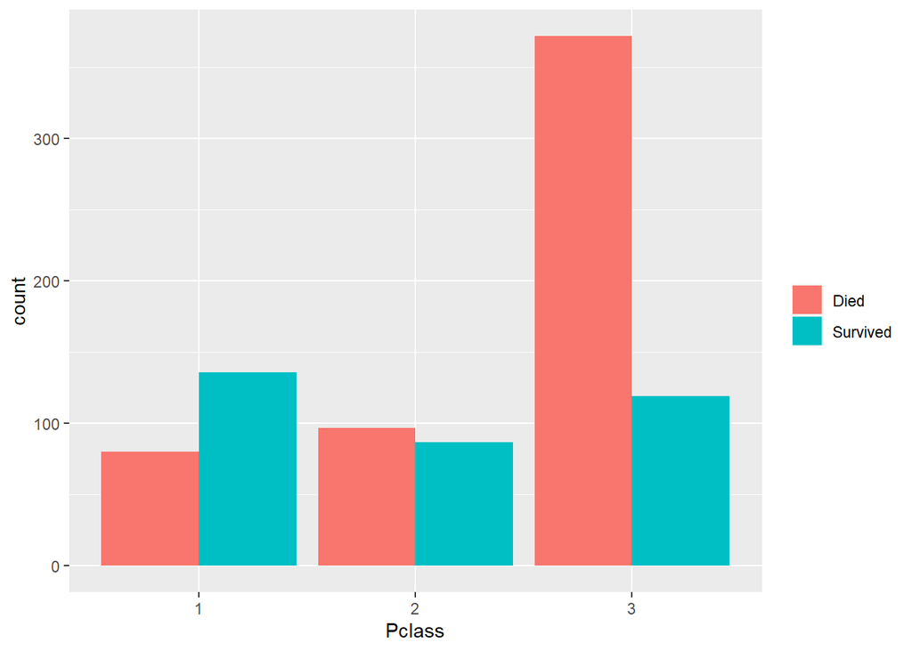

```r
ggplot(train,aes(x=as.factor(Pclass),fill=as.character(Survived)))+
  geom_bar(position="dodge")+
  scale_fill_discrete(labels=c("Died","Survived"),name = "")+
  xlab("Pclass")
```

**Sex:** Represents whether a person is a male or female. In the train and test set there are mainly males. Females had a much higher chance to survive than males. This makes sense as it is common in life and death situations for women and children to have priority.

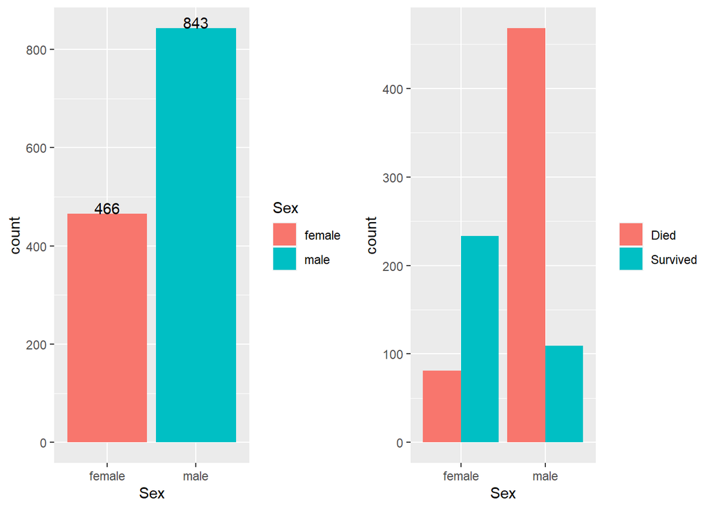

```r
sexPlot <- ggplot(combined,aes(x=Sex,fill=Sex))+
  geom_bar()+
  geom_text(stat='count', aes(label=..count..), vjust=0)

survivedBySex <- ggplot(train,aes(x=Sex,group=as.factor(Survived),fill=as.factor(Survived)))+
  geom_bar(position="dodge")+
  scale_fill_discrete(labels=c("Died","Survived"),name = "")+
  xlab("Sex")

grid.arrange(sexPlot,survivedBySex,ncol=2)
```

**Age:** Most people are in the 20-40 age range. 3.8% of the people are 4 years old or younger. The mean age of those that survived is slightly less than the average of those that died.

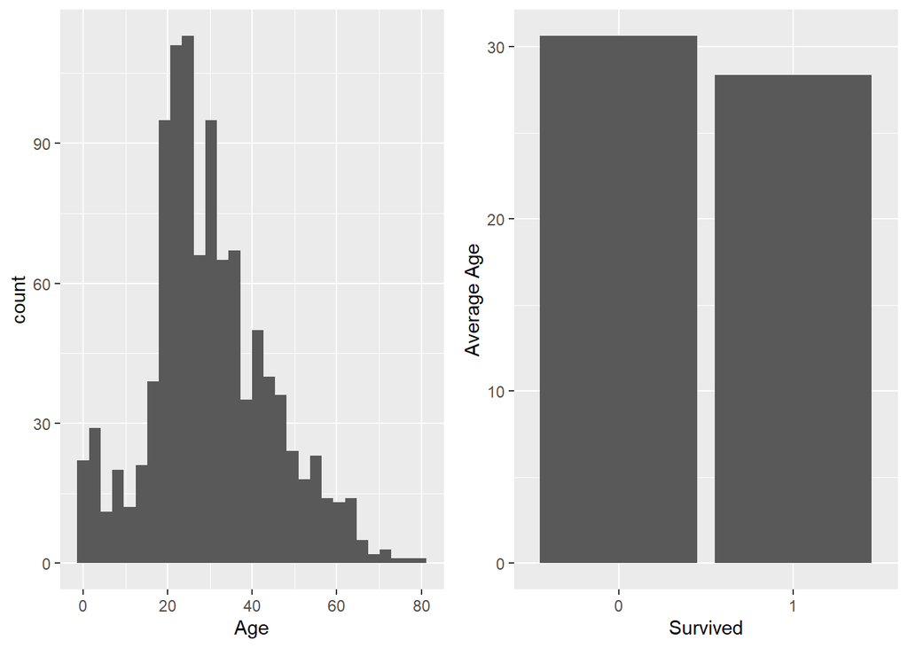

```r
ageDist <- ggplot(combined[!is.na(combined$Age),],aes(x=Age))+
  geom_histogram()

survivedByAge <- train %>% group_by(Survived) %>%
  summarize(meanAge=mean(Age,na.rm=TRUE)) %>%
ggplot(.,aes(x=as.factor(Survived),y=meanAge))+
  geom_col()+
  xlab("Survived")+
  ylab("Average Age")

grid.arrange(ageDist,survivedByAge,ncol=2)
```

**SibSp:** The sum of the number of siblings plus the number of spouses on the Titanic ship. Most have 0 meaning they had no sibling or spouses. People with 1 or 2 siblings on board had the highest percent chance to survive.

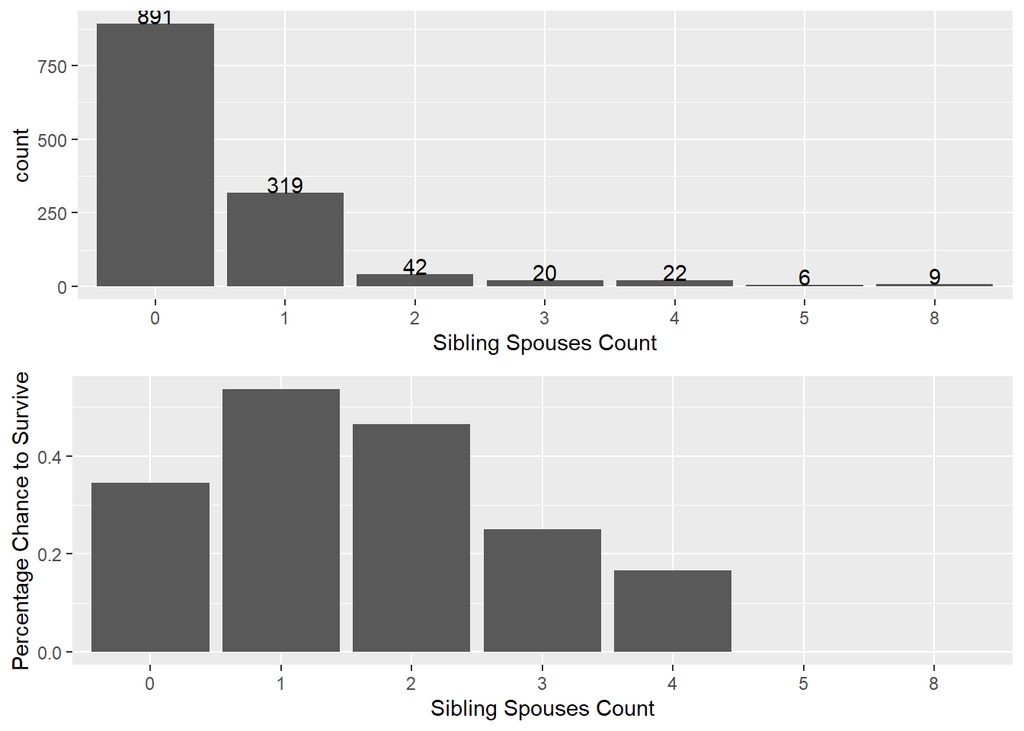

```r
sibspHist <- ggplot(combined,aes(x=factor(SibSp)))+
  geom_bar()+
  geom_text(stat='count', aes(label=..count..), vjust=0)+
  xlab("Sibling Spouses Count")


sibspSurvive <- combined %>% group_by(SibSp) %>%
  summarize(survived=mean(Survived,na.rm=TRUE)) %>%
ggplot(.,aes(x=factor(SibSp),y=survived))+
  geom_col()+
  xlab("Sibling Spouses Count")+
  ylab("Percentage Chance to Survive")

grid.arrange(sibspHist,sibspSurvive)
```

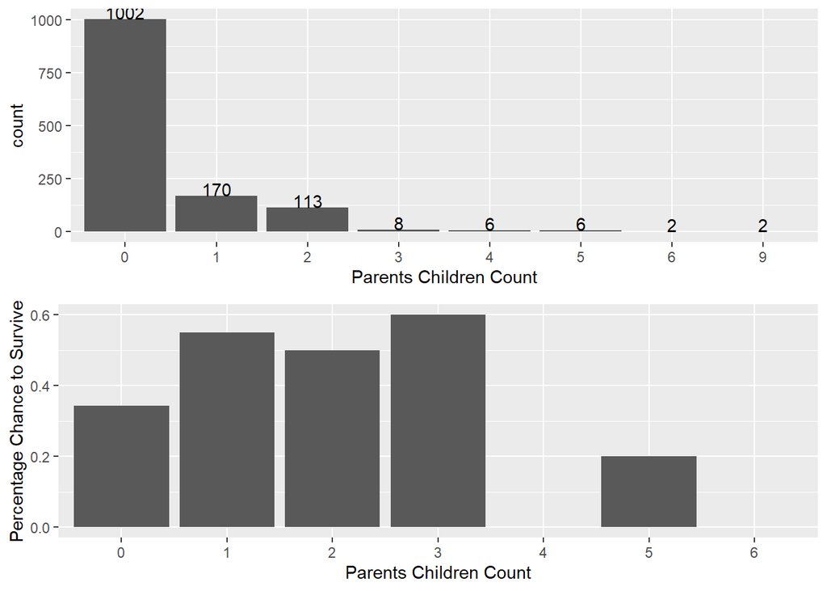

```r
ParchHist <- ggplot(combined,aes(x=factor(Parch)))+
  geom_bar()+
  geom_text(stat='count', aes(label=..count..), vjust=0)+
  xlab("Parents Children Count")


parchSurvive <- train %>% group_by(Parch) %>%
  summarize(survived=mean(Survived)) %>%
ggplot(.,aes(x=factor(Parch),y=survived))+
  geom_col()+
  xlab("Parents Children Count")+
  ylab("Percentage Chance to Survive")

grid.arrange(ParchHist,parchSurvive)
```

**Fare:** Fare is the ticket price to get on the ship. Most tickets sold were very cheap while there were a few that were very expensive. This makes the fare distribution skewed to the right. There was clearly a correlation between higher ticket price and surviving.

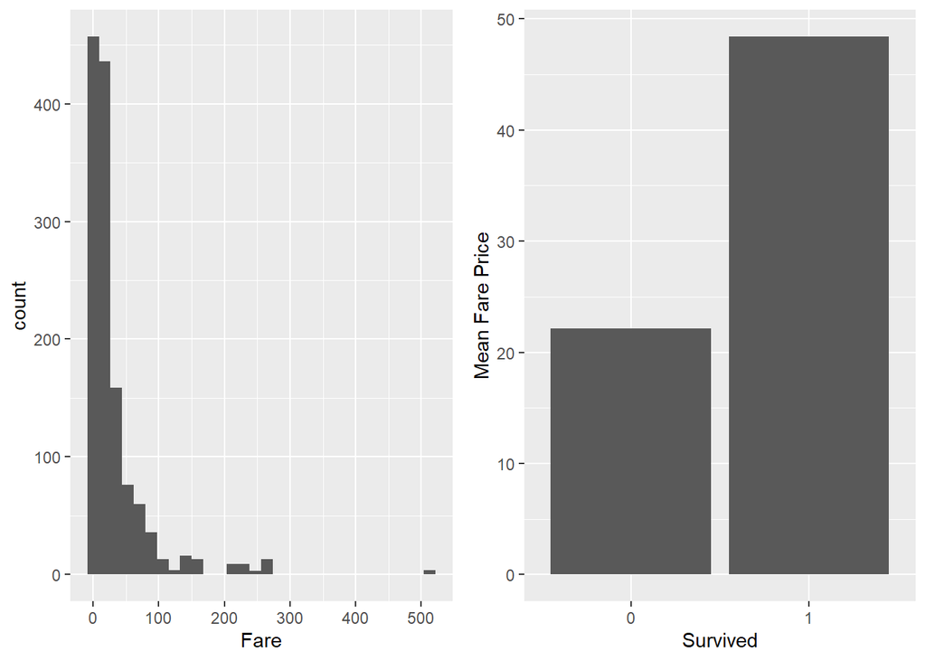

```r
fareHist <- ggplot(combined[!is.na(combined$Fare),],aes(x=Fare))+
  geom_histogram()


fareSurvived <- train %>% group_by(Survived) %>%
  summarize(meanFare=mean(Fare,na.rm=TRUE)) %>%
ggplot(.,aes(x=factor(Survived),y=meanFare))+
         geom_col()+
  xlab("Survived")+
  ylab("Mean Fare Price")

grid.arrange(fareHist,fareSurvived,ncol=2)
```

**Cabin:** Cabin number. It will be grouped by the first letter of the cabin in the feature engineering section. Here we can see that the most common section in cabin is the one with no letter. It also has the lowest survival rate at around 30%. Meanwhile, some other cabin groups have survival at around 70%.

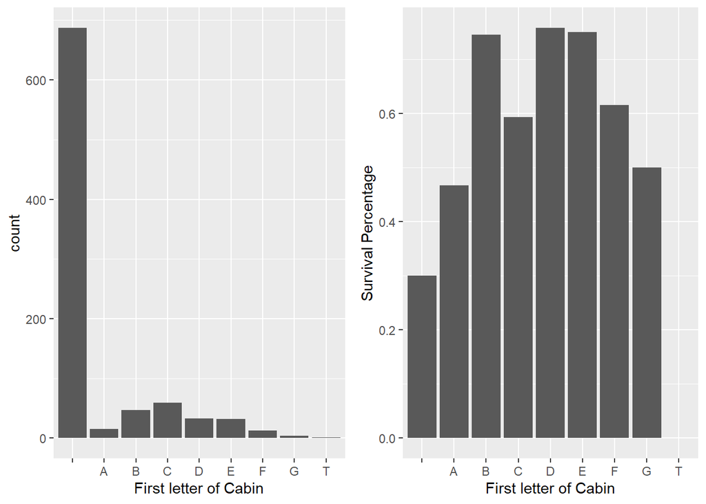

```r
countCabin <- train %>%
  mutate(firstLetter=substr(Cabin,1,1)) %>%
  group_by(firstLetter) %>%
  summarize(count=n()) %>%
  ggplot(.,aes(x=firstLetter,y=count))+
  geom_col()+
  xlab("First letter of Cabin")

survivalCabin <- train %>%
  mutate(firstLetter=substr(Cabin,1,1)) %>%
  group_by(firstLetter) %>%
  summarize(averageSurvival=mean(Survived,na.rm=TRUE)) %>%
  ggplot(.,aes(x=firstLetter,y=averageSurvival))+
  geom_col()+
  xlab("First letter of Cabin")+
  ylab("Survival Percentage")
grid.arrange(countCabin,survivalCabin,ncol=2)
```

The fare and cabin area by first letter are found to be correlated. One of the cheapest cabin areas, or the no name cabin area, was also one of the cheapest sections. Meanwhile, the high survival cabin areas were the most expensive and had the highest survival rates.

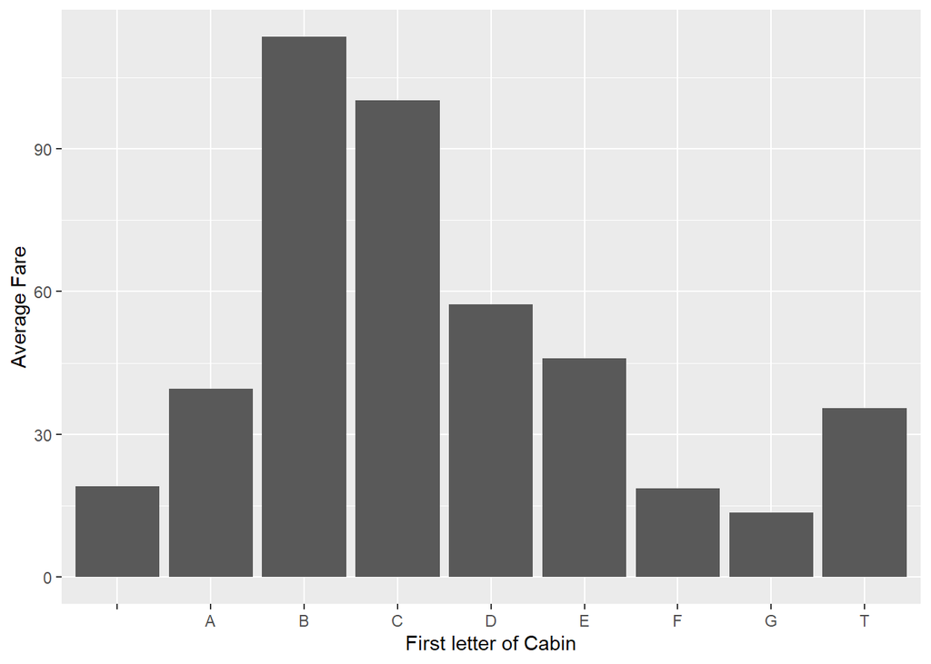

```r
train %>%
  mutate(firstLetter=substr(Cabin,1,1)) %>%
  group_by(firstLetter) %>%
  summarize(averageFare=mean(Fare)) %>%
  ggplot(.,aes(x=firstLetter,y=averageFare))+
  geom_col()+
  xlab("First letter of Cabin")+
  ylab("Average Fare")
```

**Embarked:** Represents where a person embarked on the ship. It contains 2 blank values that are not NA’s. These values will be replaced in the imputation section. It appears people who boarded in Cherbours had a higher survival rate than people that boarded in Queenstown or Southampton. This can be explained from Cherbourg having the highest average ticket price. However, tickets were more expensive in Southampton than Queenstown, but did not result in a higher survival rate.

- C = Cherbourg
- Q = Queenstown
- S = Southampton

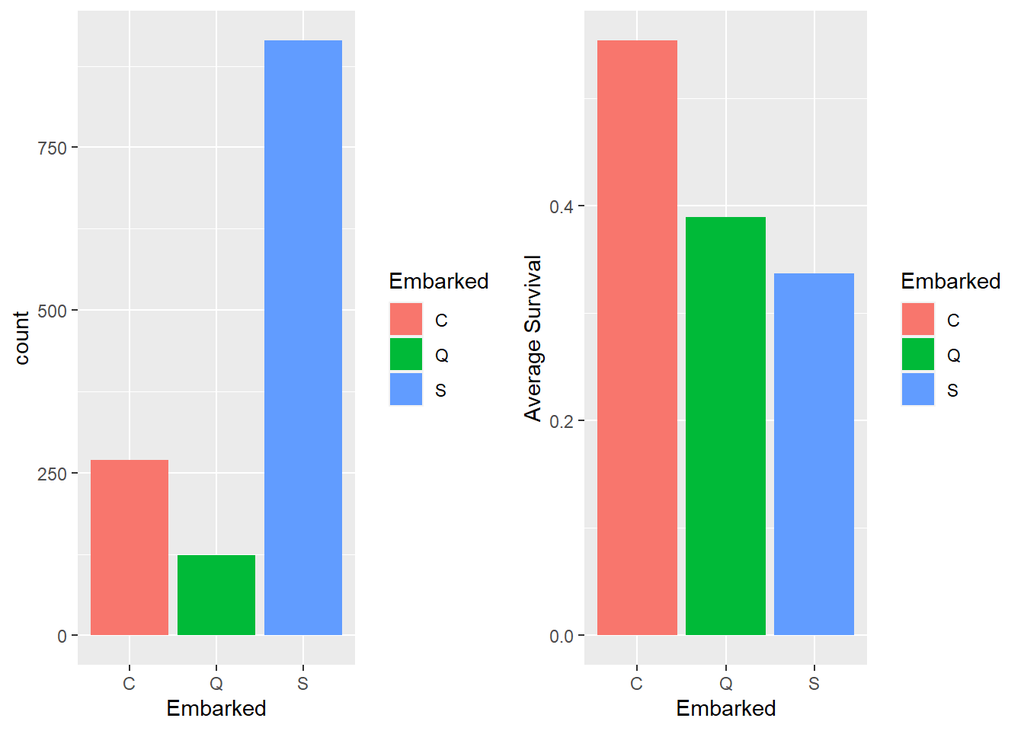

```r
embarkedCount <- ggplot(combined[combined$Embarked!="",],aes(x=Embarked,fill=Embarked))+
  geom_bar()

embarkedSurvival <- train %>% group_by(Embarked) %>%
  summarize(averageSurvival=mean(Survived)) %>%
  filter(Embarked!="") %>%
ggplot(.,aes(x=Embarked,y=averageSurvival,fill=Embarked))+
  geom_col()+
  ylab("Average Survival")

grid.arrange(embarkedCount,embarkedSurvival,ncol=2)
```

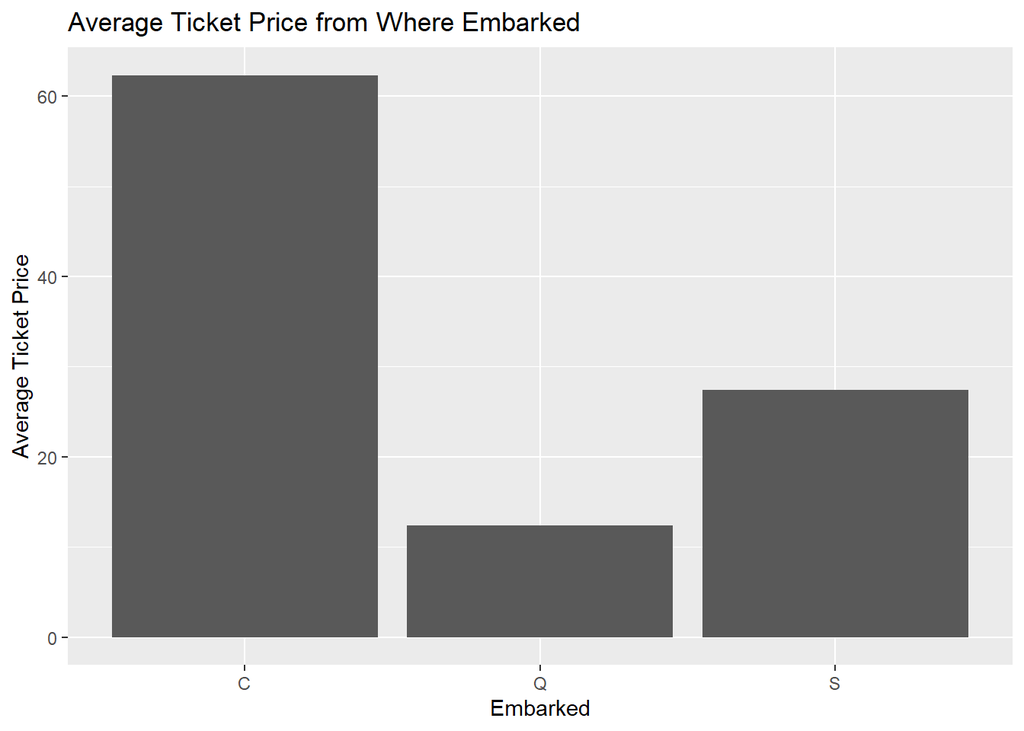

```r
combined %>% group_by(Embarked) %>%
  summarize(averagePrice=mean(Fare,na.rm=TRUE)) %>%
  filter(Embarked!="") %>%
  ggplot(.,aes(x=Embarked,y=averagePrice))+
  geom_col()+
  labs(title="Average Ticket Price from Where Embarked")+
  ylab("Average Ticket Price")
```

**Name:** Name of individual persons on the Titanic. If the title of the person is extracted out, there does appear to be a difference in survival rate from a persons title.

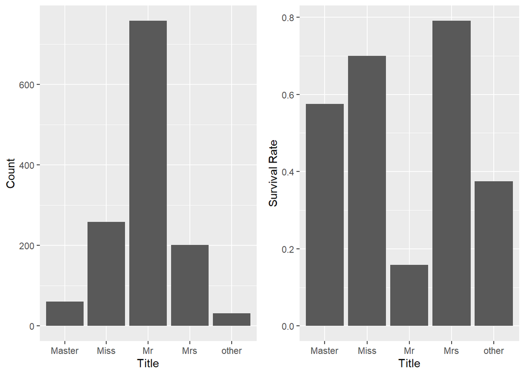

```r
titleCount <- combined %>%
  mutate(title=ifelse(grepl("MR",toupper(Name))==TRUE & grepl("MRS",toupper(Name))==FALSE,"Mr",ifelse(grepl("MRS",toupper(Name))==TRUE,"Mrs",ifelse(grepl("MISS",toupper(Name)),"Miss",ifelse(grepl("MASTER",toupper(Name))==TRUE,"Master","other"))))) %>%
  group_by(title) %>%
  summarize(count=n()) %>%
  ggplot(.,aes(x=title,y=count))+
  geom_col()+
  ylab("Count")+
  xlab("Title")


titleSurvival <- combined %>%
  mutate(title=ifelse(grepl("MR",toupper(Name))==TRUE & grepl("MRS",toupper(Name))==FALSE,"Mr",ifelse(grepl("MRS",toupper(Name))==TRUE,"Mrs",ifelse(grepl("MISS",toupper(Name)),"Miss",ifelse(grepl("MASTER",toupper(Name))==TRUE,"Master","other"))))) %>%
  group_by(title) %>%
  summarize(survivedRatio=mean(Survived,na.rm=TRUE)) %>%
  ggplot(.,aes(x=title,y=survivedRatio))+
  geom_col()+
  ylab("Survival Rate")+
  xlab("Title")

grid.arrange(titleCount,titleSurvival,ncol=2)
```

# 6 Feature Engineering

## 6.1 Created Features

**title:** Title will be replacing name which is the title of the person extracted out from their name. The name predictor will be dropped.

```r
combined <- combined %>%
  mutate(title=ifelse(grepl("MR",toupper(Name))==TRUE & grepl("MRS",toupper(Name))==FALSE,"Mr",ifelse(grepl("MRS",toupper(Name))==TRUE,"Mrs",ifelse(grepl("MISS",toupper(Name)),"Miss",ifelse(grepl("MASTER",toupper(Name))==TRUE,"Master","other")))))

combined <- combined %>% select(-Name)
```

**cabinLetters:** Creating a feature based off first letter of cabin. The people who did not have a cabin number had a lower survival probability.

```r
#pulling first letter
combined <- combined %>%
  mutate(cabinLetters=substr(Cabin,1,1))

table(combined$cabinLetters)
```

```
##
##         A    B    C    D    E    F    G    T
## 1014   22   65   94   46   41   21    5    1
```

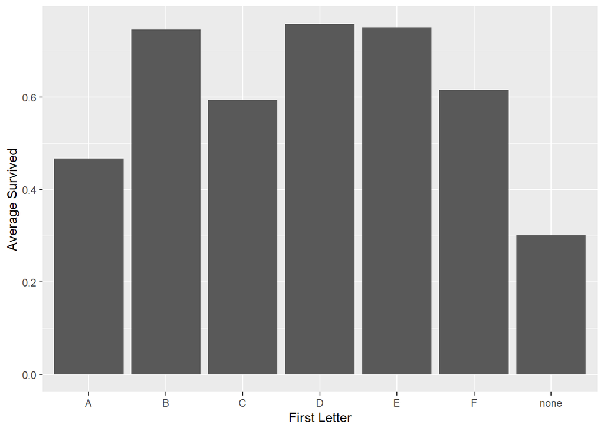

```r
#setting rare labels to mode
combined[combined$cabinLetters %in% c("G","T"),"cabinLetters"] <- ""
#replacing blank space factor with "none"
combined[combined$cabinLetters=="","cabinLetters"] <- "none"

combined %>% group_by(cabinLetters) %>%
  summarize(averageSurvived=mean(Survived,na.rm=TRUE)) %>%
ggplot(.,aes(x=cabinLetters,y=averageSurvived))+
  geom_col()+
  xlab("First Letter")+
  ylab("Average Survived")
```

**cabinNumbers:** A feature will be created based off the numbers of the cabin number. Any cabin that didn’t have a number is assigned a value of 0, numbers above 75 were assigned a value of 1, and numbers below 75 were assigned a value of 2. It appears people with no cabin number had a lower survival rate than those with a cabin number. Also, people with a higher cabin number seemed to be less likely to survive than a lower cabin number. This might be because higher numbers were all towards a certain side of the ship. The cabin feature will then be dropped.

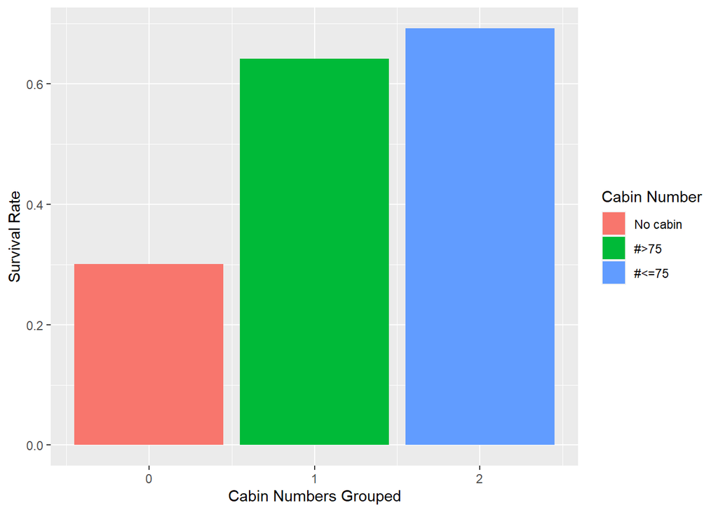

```r
combined <- combined %>%
  mutate(cabinNumbers=substr(word(Cabin,1),2,nchar(word(Cabin,1))))

combined[combined$cabinNumbers=="","cabinNumbers"] <- 0

combined$cabinNumbers <- as.integer(combined$cabinNumbers)

combined[combined$cabinNumbers!=0 & combined$cabinNumbers<=75,"cabinNumbers"] <- 2

combined[combined$cabinNumbers>75,"cabinNumbers"] <- 1

combined %>% group_by(cabinNumbers) %>%
  summarize(averageSurvived=mean(Survived,na.rm=TRUE)) %>%
ggplot(.,aes(x=cabinNumbers,y=averageSurvived,fill=as.character(cabinNumbers)))+
  geom_col()+
  scale_fill_discrete(labels=c('No cabin', '#>75', '#<=75'))+
  guides(fill=guide_legend(title="Cabin Number"))+
  xlab("Cabin Numbers Grouped")+
  ylab("Survival Rate")
```

```r
#dropping Cabin
combined <- combined %>% select(-Cabin)
```

**hasSibSp:** A predictor will be made for whether or not a person had a sibling or spouse on board the ship. It appears people who had at least one or more siblings or spouses had a higher survival percentage. This could be caused by increased coordination among them.

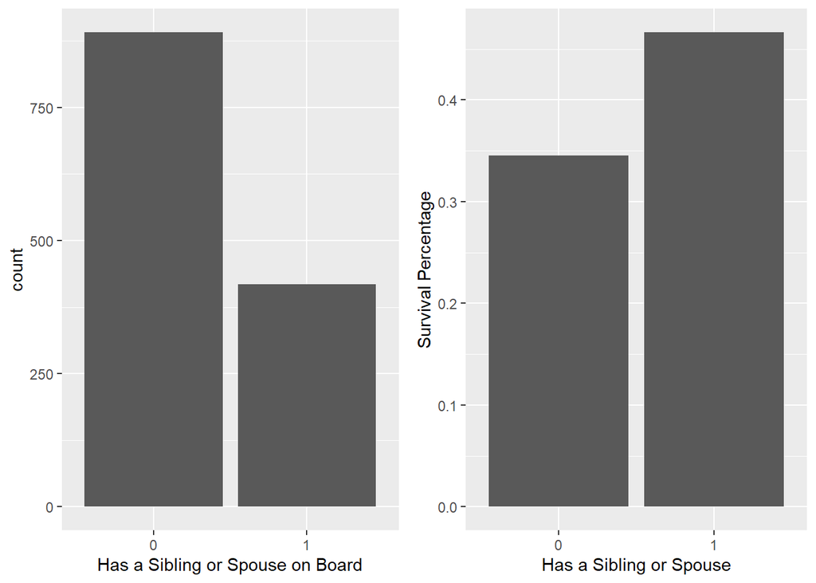

```r
combined <- combined %>%
  mutate(hasSibSp=ifelse(SibSp==0,0,1))

hasSibSpCount <- ggplot(combined,aes(x=as.character(hasSibSp)))+
  geom_bar()+
  xlab("Has a Sibling or Spouse on Board")

survivedSibSpCount <-
  combined %>% group_by(hasSibSp) %>%
  summarize(averageSurvived=mean(Survived,na.rm=TRUE)) %>% ggplot(.,aes(x=as.character(hasSibSp),y=averageSurvived))+
              geom_col()+
  xlab("Has a Sibling or Spouse")+
  ylab("Survival Percentage")

grid.arrange(hasSibSpCount,survivedSibSpCount,ncol=2)
```

# 7 Imputation

## 7.1 Linear Regression Imputation for Age

Age contained 263 NA values. A linear regression model will be built using the predictors Pclass and SibSp as they have some correlation with age.

```r
# predicting age with lm

ageMod <- lm(Age~Pclass+SibSp, data=combined,na.action = "na.omit")
saveRDS(ageMod,"ageMod.rds")
ageMod
```

```
##
## Call:
## lm(formula = Age ~ Pclass + SibSp, data = combined, na.action = "na.omit")
##
## Coefficients:
## (Intercept)       Pclass        SibSp
##      46.697       -6.808       -3.554
```

```r
# imputing missing values in age
combined[is.na(combined$Age),"Age"] <-
predict(ageMod,combined[is.na(combined$Age),])
```

## 7.2 Imputation for Fare and Embarked

Since Fare only contained 1 NA value, the most highly correlated predictor will be used for imputation. Since the Pclass value is the highest correlation, the median Fare value for when Pclass is equal to 3 will be used.

```r
#correlations with fare
for(name in names(combined)){
  if(is.numeric(combined[,name])){
    print(name)
    print(cor(combined[,name],combined[,"Fare"],use="complete.obs"))
  }
}
```

```
## [1] "Survived"
## [1] 0.2573065
## [1] "Pclass"
## [1] -0.5586287
## [1] "Age"
## [1] 0.1807183
## [1] "SibSp"
## [1] 0.1602383
## [1] "Parch"
## [1] 0.2215387
## [1] "Fare"
## [1] 1
## [1] "cabinNumbers"
## [1] 0.496833
## [1] "hasSibSp"
## [1] 0.2118039
```

```r
combined[is.na(combined$Fare),]
```

```
##      Survived Pclass  Sex  Age SibSp Parch Fare Embarked title cabinLetters
## 1044       NA      3 male 60.5     0     0   NA        S    Mr         none
##      cabinNumbers hasSibSp
## 1044            0        0
```

```r
combined[is.na(combined$Fare),"Fare"] <- median(train[train$Pclass==3,"Fare"])
```

Embarked contained two observations that had a blank label. When looking at the different average ticket price by where embarked, we can see there is a large difference. Using this large difference we can make a guess that the two blank values boarded on the highest prices embarking area which was “C”.

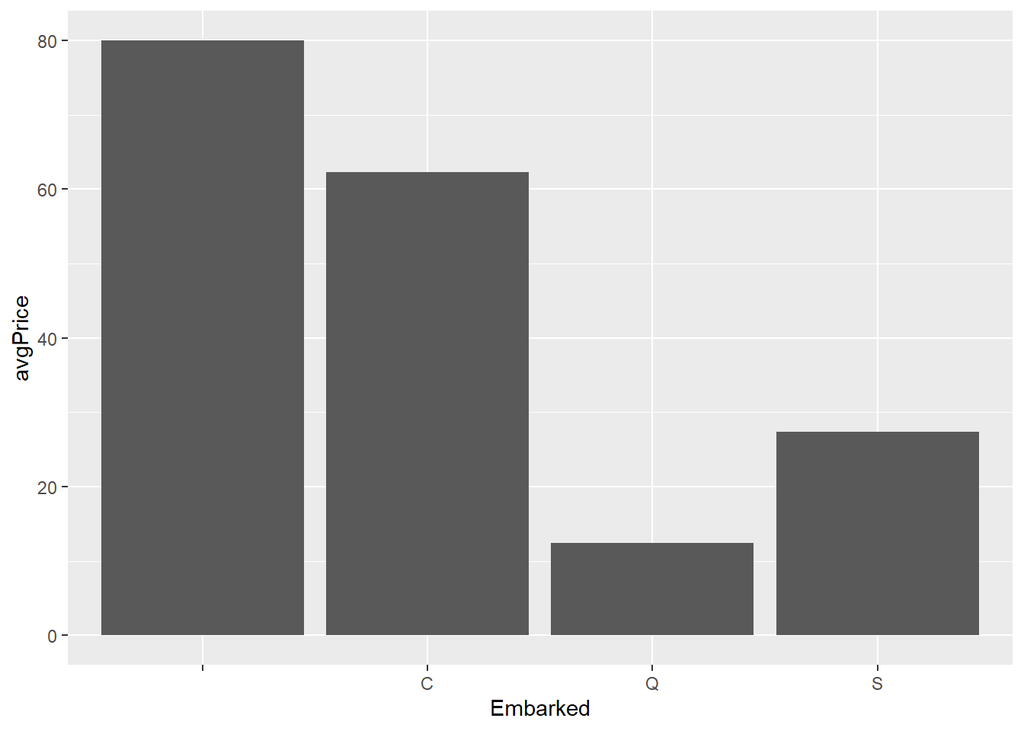

```r
combined %>% group_by(Embarked) %>% summarize(avgPrice=mean(Fare,na.rm=TRUE)) %>%
ggplot(.,aes(x=Embarked,y=avgPrice))+
  geom_col()
```

```r
combined[combined$Embarked=="","Embarked"] <- "C"
```

# 8 Feature Engineering #2

## 8.1 Creating Features

**parent:** Anybody that has one or more in the parent or children variable and is also over 18 will be labeled as a parent. It seems parents had priority of life rafts as they had a slightly higher survival rate.

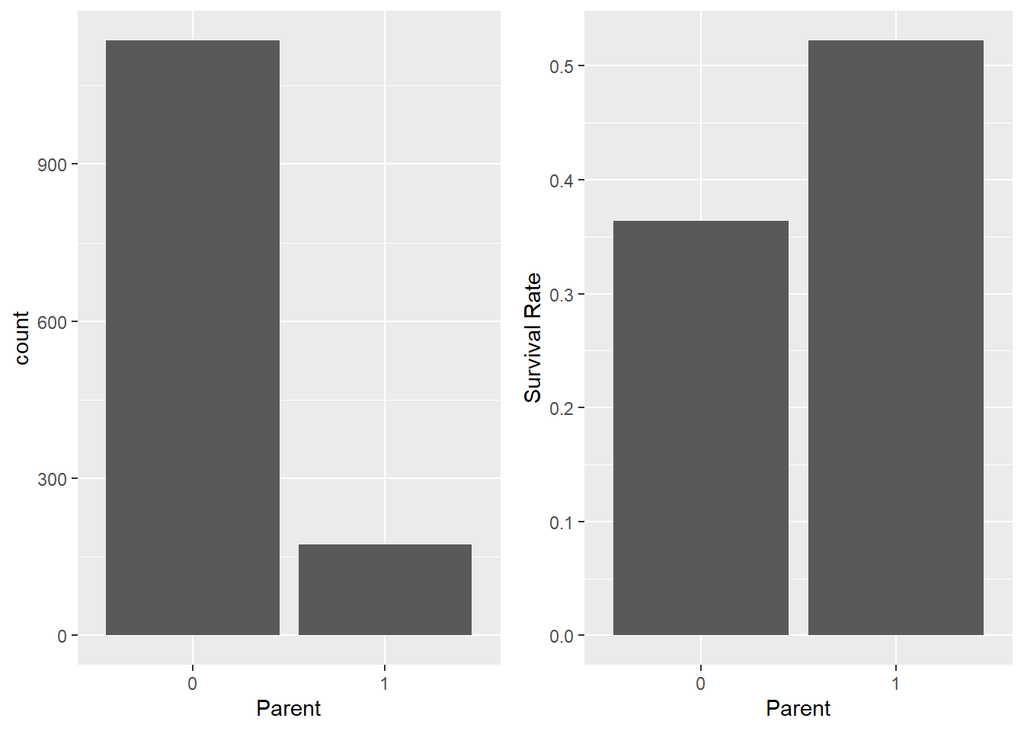

```r
combined <- combined %>%
  mutate(parent=ifelse(Age>18 & Parch>0,1,0))

parentCount <- ggplot(combined,aes(x=as.character(parent)))+
  geom_bar()+
  xlab("Parent")

parentSurvival <- combined %>% group_by(parent) %>%
  summarize(survivalRate=mean(Survived,na.rm=TRUE)) %>%
  ggplot(.,aes(x=as.character(parent),y=survivalRate))+
  geom_col()+
  xlab("Parent")+
  ylab("Survival Rate")

grid.arrange(parentCount,parentSurvival,ncol=2)
```

Sex will be made into an factor variable of 0’s and 1’s instead of male and female.

```r
combined[combined$Sex=="male","Sex"] <- 1
combined[combined$Sex=="female","Sex"] <- 0

combined$Sex <- as.integer(combined$Sex)
```

# 9 Correlation Plot

There doesn’t seem to be many high correlations among the variables. The highest correlation is negative and between cabin numbers and socio-economic class (Pclass).

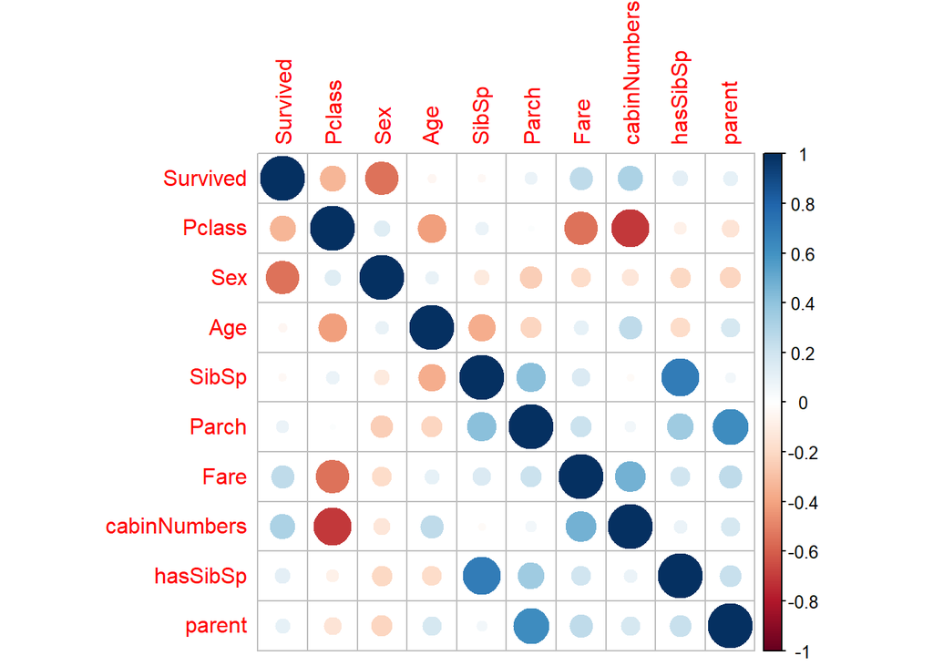

```r
numericVariables <- combined[!is.na(combined$Survived),] %>% select_if(is.numeric)

corrplot(cor(numericVariables))
```

# 10 Preparing for Modeling

In the modeling section we will be using the caret package which needs all variables to be in numeric form. On top of that we will be centering and scaling our variables.

## 10.1 Train/Test split

Dividing the combined data set back to train and test.

```r
train <- combined[1:nrow(train),]
test <- combined[(nrow(train)+1):nrow(combined),]
```

## 10.2 Numeric Predictors

Centering, scaling, and Box-Cox will be applied to non-ordinal numeric predictors. These variables are Age, SibSp, Parch, and Fare.

```r
centerScale <- preProcess(train[,c("Age","SibSp","Parch","Fare")],method=c("BoxCox","center","scale"))

saveRDS(centerScale,"centerScale.rds")

train <- predict(centerScale,train)
test <- predict(centerScale,test)
```

## 10.3 Ordinal Predictors

The ordinal predictors are Pclass, cabinNumbers, hasSibSp, parent, and Sex. These are marked as ordinal because as the number decreases or increases we can expect an increase or decease in survival rate. Only Pclass is not on a scale starting from 0 so will be changed from its current scale of 1-3 to 0-2.

```r
#converting from 1-3 to 0-2

train <- train %>% mutate(Pclass=Pclass-1)
test <- test %>% mutate(Pclass=Pclass-1)
```

## 10.4 Nominal Variables

The character variables of Embarked and cabin letters will be converted into factors and then dummy variables using the caret package.

```r
train$Embarked <- as.factor(train$Embarked)
train$cabinLetters <- as.factor(train$cabinLetters)
train$title <- as.factor(train$title)

test$Embarked <- as.factor(test$Embarked)
test$cabinLetters <- as.factor(test$cabinLetters)
test$title <- as.factor(test$title)

dummied <- dummyVars(~.,train,fullRank = TRUE)
saveRDS(dummied,"dummied.rds")

train <- predict(dummied,train)
test <- predict(dummied,test)

train <- as.data.frame(train)
test <- as.data.frame(test)

kable(head(train))
```

| Survived | Pclass | Sex | Age | SibSp | Parch | Fare | Embarked.Q | Embarked.S | title.Miss | title.Mr | title.Mrs | title.other | cabinLetters.B | cabinLetters.C | cabinLetters.D | cabinLetters.E | cabinLetters.F | cabinLetters.none | cabinNumbers | hasSibSp | parent |
| --- | --- | --- | --- | --- | --- | --- | --- | --- | --- | --- | --- | --- | --- | --- | --- | --- | --- | --- | --- | --- | --- |
| 0 | 2 | 1 | -0.5284349 | 0.4325504 | -0.4734077 | -0.5021631 | 0 | 1 | 0 | 1 | 0 | 0 | 0 | 0 | 0 | 0 | 0 | 1 | 0 | 1 | 0 |
| 1 | 0 | 0 | 0.6520876 | 0.4325504 | -0.4734077 | 0.7864036 | 0 | 0 | 0 | 0 | 1 | 0 | 0 | 1 | 0 | 0 | 0 | 0 | 1 | 1 | 0 |
| 1 | 2 | 0 | -0.2333042 | -0.4742788 | -0.4734077 | -0.4885799 | 0 | 1 | 1 | 0 | 0 | 0 | 0 | 0 | 0 | 0 | 0 | 1 | 0 | 0 | 0 |
| 1 | 0 | 0 | 0.4307396 | 0.4325504 | -0.4734077 | 0.4204941 | 0 | 1 | 0 | 0 | 1 | 0 | 0 | 1 | 0 | 0 | 0 | 0 | 1 | 1 | 0 |
| 0 | 2 | 1 | 0.4307396 | -0.4742788 | -0.4734077 | -0.4860644 | 0 | 1 | 0 | 1 | 0 | 0 | 0 | 0 | 0 | 0 | 0 | 1 | 0 | 0 | 0 |
| 0 | 2 | 1 | -0.2131931 | -0.4742788 | -0.4734077 | -0.4778481 | 1 | 0 | 0 | 1 | 0 | 0 | 0 | 0 | 0 | 0 | 0 | 1 | 0 | 0 | 0 |

The dependent variable will be made into a factor.

```r
train$Survived <- as.factor(train$Survived)
```

# 11 Modeling

## 11.1 Train Control

Ten-fold cross validation repeated two times will be used for validation.

```r
ctrl <- trainControl(method="repeatedcv",number=10,
                     repeats=2)
```

## 11.2 Random Forest

From the random forest model we are able to extract variable importance. It labels the predictors fare, age, sex, and title as the most important predictors in deciding whether or not a person survived. The train accuracy achieved was 83.6%.

```r
set.seed(123)
rfMod <- train(Survived~.,data=train,
                     method="rf",
                     tuneGrid=expand.grid(mtry=2:ncol(train)-1),
                     trControl=ctrl)

saveRDS(rfMod,"rfMod.rds")
```

```r
rfMod <- readRDS("rfMod.rds")
max(rfMod$results$Accuracy)
```

```
## [1] 0.8360873
```

```r
varImp(rfMod)
```

```
## rf variable importance
##
##   only 20 most important variables shown (out of 21)
##
##                   Overall
## Fare              100.000
## Age                93.746
## Sex                84.905
## title.Mr           82.254
## Pclass             40.032
## SibSp              22.730
## cabinNumbers       17.894
## title.Mrs          11.609
## Embarked.S         11.220
## Parch              11.076
## cabinLetters.none  10.903
## title.Miss         10.323
## title.other         6.788
## hasSibSp            6.488
## parent              5.110
## Embarked.Q          4.596
## cabinLetters.C      3.275
## cabinLetters.E      3.219
## cabinLetters.D      1.994
## cabinLetters.B      1.963
```

## 11.3 Logistic Regression

The logistic regression model achieved an accuracy of 82.7%, slightly worse than the random forest model.

```r
set.seed(4321)
logisticMod <- train(Survived~.,data=train,
                     method="glm",
                     family="binomial",
                     trControl=ctrl)
saveRDS(logisticMod,"logisticMod.rds")
```

```r
logisticMod <- readRDS("logisticMod.rds")
logisticMod
```

```
## Generalized Linear Model
##
## 891 samples
##  21 predictor
##   2 classes: '0', '1'
##
## No pre-processing
## Resampling: Cross-Validated (10 fold, repeated 2 times)
## Summary of sample sizes: 802, 801, 803, 802, 802, 801, ...
## Resampling results:
##
##   Accuracy   Kappa
##   0.8266631  0.631833
```

## 11.4 Gradient Boosting

The gradient boost model performed the best of the train data with an accuracy of 83.9%.

```r
set.seed(8723)
gbmMod <- train(Survived~., data=train, method='gbm', tuneLength=12, trControl=ctrl, verbose=FALSE)

saveRDS(gbmMod,"gbmMod.rds")
```

```r
gbmMod <- readRDS("gbmMod.rds")
max(gbmMod$results$Accuracy)
```

```
## [1] 0.8394839
```

## 11.5 SVM

The SVM model did not perform as well the other models with an accuracy of 82.3%.

```r
set.seed(20174)
svmMod <- train(Survived~., data=train, method='svmRadial', trControl=ctrl,tuneLength=7)
saveRDS(svmMod,"svmMod.rds")
```

```r
svmMod <- readRDS("svmMod.rds")
max(svmMod$results$Accuracy)
```

```
## [1] 0.8232376
```

## 11.6 Results Modeling #1

Gradient Boosted model performed the best of the four in the first modeling section.

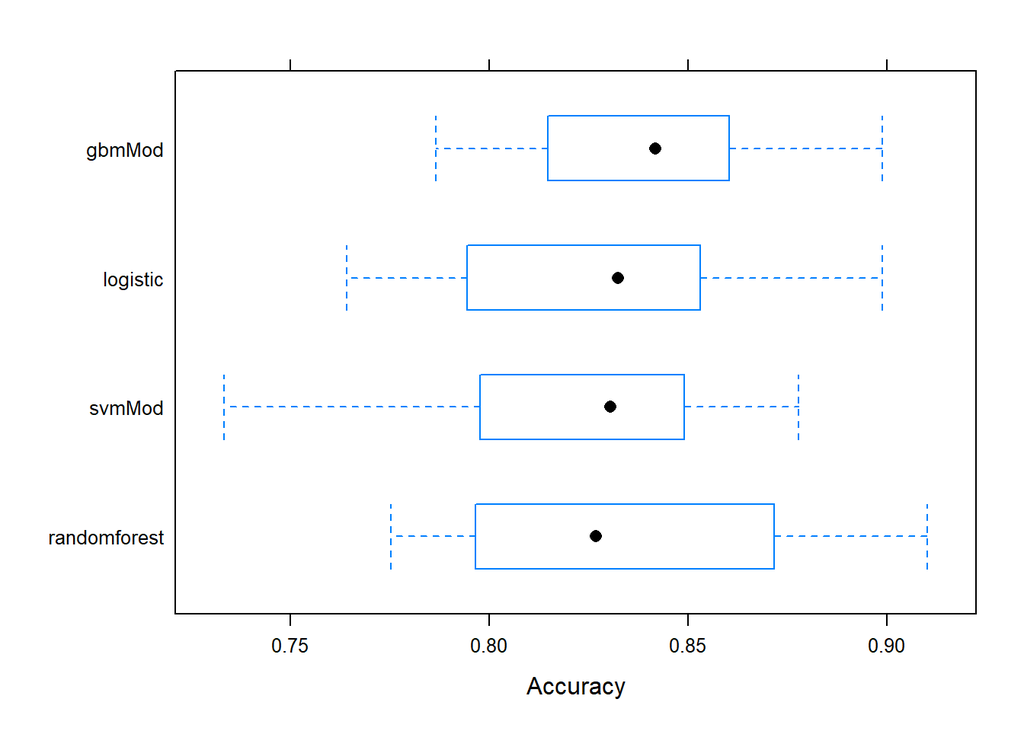

```r
modelResults <- resamples(list(randomforest=rfMod,
                               logistic=logisticMod,
                            gbmMod=gbmMod,
                            svmMod=svmMod))
bwplot(modelResults,metric="Accuracy")
```

# 12 Feature Engineering 3

## 12.1 Creating New Variables

**fareGrouped:** Since fare was one of the top predictors another predictor will be made grouping the fare variable based off different groups in the histogram.

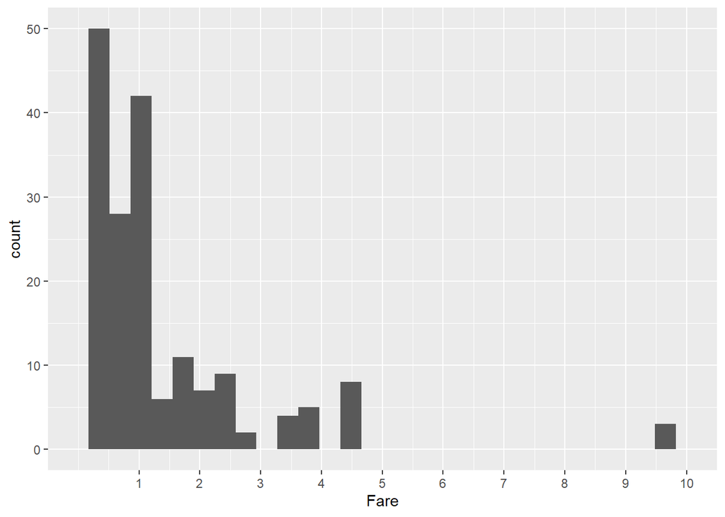

```r
ggplot(train,aes(x=Fare))+
  geom_histogram()+
  scale_x_continuous(limits=c(0,10),breaks=c(1,2,3,4,5,6,7,8,9,10))
```

```r
train <- train %>%
  mutate(fareGrouped=ifelse(Fare<1.5,0,ifelse(
    Fare>=1.5 & Fare<3,1,ifelse(
      Fare>=3 & Fare<4,2,3))))

test <- test %>%
  mutate(fareGrouped=ifelse(Fare<1.5,0,ifelse(
    Fare>=1.5 & Fare<3,1,ifelse(
      Fare>=3 & Fare<4,2,3))))
```

**motherFather:** Since sex was a top 5 predictor in terms of variable importance in the random forest model, a variable will be made based on if a parent was a father, mother, or neither. Then this newly created variable will be dummied.

```r
train <- train %>%
  mutate(motherFather=ifelse(parent==1 & Sex==1,"Father",
                             ifelse(parent==1 & Sex==0,"Mother","notParent")))

test <- test %>%
  mutate(motherFather=ifelse(parent==1 & Sex==1,"Father",
                             ifelse(parent==1 & Sex==0,"Mother","notParent")))

train$motherFather <- as.factor(train$motherFather)
test$motherFather <- as.factor(test$motherFather)

# make dummy variable
dummied <- dummyVars(~motherFather,train)
saveRDS(dummied,"motherFather.rds")

train <- cbind(train,as.data.frame(predict(dummied,train)))
#dropping non-dummied variable
train <- train %>% select(-motherFather)

test <- cbind(test,as.data.frame(predict(dummied,test)))
#dropping non-dummied variable
test <- test %>% select(-motherFather)
```

# 13 Modeling #2

## 13.1 Random Forest

```r
set.seed(2525)
rfMod2 <- train(Survived~.,data=train,
                     method="rf",
                     tuneGrid=expand.grid(mtry=2:ncol(train)-1),
                     trControl=ctrl)

saveRDS(rfMod2,"rfMod2.rds")
```

```r
rfMod2 <- readRDS("rfMod2.rds")
max(rfMod2$results$Accuracy)
```

```
## [1] 0.8383294
```

## 13.2 Logistic Regression

```r
set.seed(42421)
logisticMod2 <- train(Survived~.,data=train,
                     method="glm",
                     family="binomial",
                     trControl=ctrl)

saveRDS(logisticMod2,"logisticMod2.rds")
```

```r
logisticMod2 <- readRDS("logisticMod2.rds")
max(logisticMod2$results$Accuracy)
```

```
## [1] 0.822686
```

## 13.3 Gradient Boosting

```r
set.seed(87232)
gbmMod2 <- train(Survived~., data=train, method='gbm', tuneLength=12, trControl=ctrl, verbose=FALSE)

saveRDS(gbmMod2,"gbmMod2.rds")
```

```r
gbmMod2 <- readRDS("gbmMod2.rds")
max(gbmMod2$results$Accuracy)
```

```
## [1] 0.8366899
```

## 13.4 SVM

```r
set.seed(20174)
svmMod2 <- train(Survived~., data=train, method='svmRadial', trControl=ctrl,tuneLength=7)

saveRDS(svmMod2,"svmMod2.rds")
```

```r
svmMod2 <- readRDS("svmMod2.rds")
max(svmMod2$results$Accuracy)
```

```
## [1] 0.810884
```

## 13.5 Results Modeling #2

The two best performing modeling were the gradient boost and logistic regression from the first modeling phase. The added predictors from the third feature engineering section hurt these two models. Meanwhile, with the added predictors the random forest model appeared to perform slightly better.

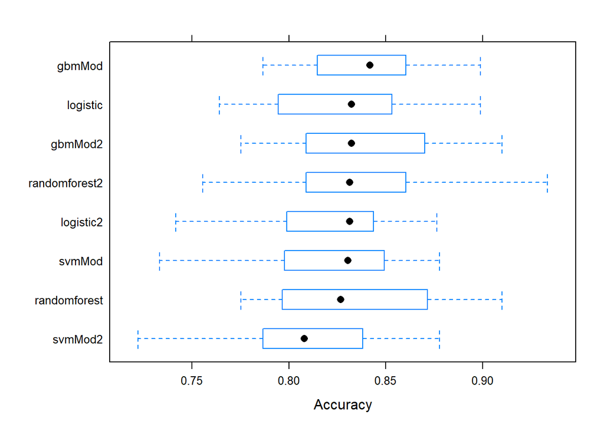

```r
modelResults2 <- resamples(list(randomforest=rfMod,
                                randomforest2=rfMod2,
                               logistic=logisticMod,
                               logistic2=logisticMod2,
                               gbmMod=gbmMod,
                               gbmMod2=gbmMod2,
                               svmMod=svmMod,
                               svmMod2=svmMod2))


bwplot(modelResults2,metric="Accuracy")
```

A correlation plot is made of the final models. Weak correlation signify that the models made a large number of different predictions. By combining models with weak correlations it is possible to achieve a higher prediction accuracy.

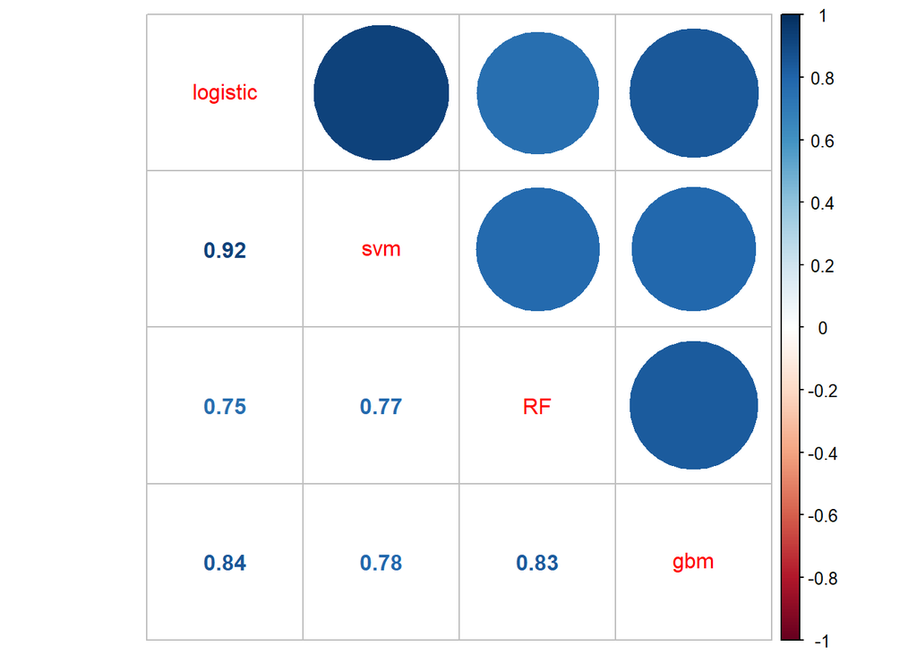

```r
#as.numeric turns to 1's and 0's
predictionDF <- data.frame(RF=as.numeric(predict(rfMod2,test))-1,logistic=as.numeric(predict(logisticMod,test))-1,gbm=as.numeric(predict(gbmMod,test))-1,svm=as.numeric(predict(svmMod,test))-1)

corrplot.mixed(cor(predictionDF[,c("RF","logistic","gbm","svm")]),order="hclust")
```

# 14 Ensemble for Predictions

An ensemble model is created using the four models. Since most of the people on the titanic died, a voting system will be used requiring three of the four models to predict survived in order for a prediction of survived. Otherwise, it will predict did not survive. The final submission will be based off these results.

```r
predictionDF$vote <- ifelse(predictionDF$RF+predictionDF$gbm+predictionDF$logistic+predictionDF$svm>=3,1,0)
# creating final submission
outputdf <- data.frame(PassengerId=PassengerId,Survived=predictionDF$vote)
write.csv(outputdf,"submission1.csv",row.names = FALSE)
```